# Sersic Galaxy Fitting (Work In Progress)

```python
def two_component_model(x, y, params):
    # params = [I_e_bulge, R_e_bulge, n_bulge, I_e_disk, R_e_disk, x0, y0]
    I_e_bulge, R_e_bulge, n_bulge, I_e_disk, R_e_disk, n_disk, x0, y0 = params
    bulge = sersic_2d(x, y, I_e_bulge, R_e_bulge, n_bulge, x0, y0)
    disk = sersic_2d(x, y, I_e_disk, R_e_disk, n_disk, x0, y0)
    return bulge + disk

def residuals_two_components(params, x, y, data):
    model = two_component_model(x, y, params)
    return (model - data).ravel()

p1 = [np.max(data), 50, 4, np.max(data)/1.5, 200, 1, 500, 500]
bounds_lower = [0, 1, .5, 0, 10, .5, 0, 0]
bounds_upper = [np.inf, 200, 8, np.inf, 500, 8, data.shape[1], data.shape[0]]


result = least_squares(residuals_two_components, p1, args=(x, y, data), bounds=(bounds_lower, bounds_upper))

I_e_bulge_fit, R_e_bulge_fit, n_bulge_fit, I_e_disk_fit, R_e_disk_fit, n_disc_fit, x0_fit, y0_fit = result.x

print(f"Fit results:")
print(f"Bulge: I_e={I_e_bulge_fit:.2f}, R_e={R_e_bulge_fit:.2f}, n={n_bulge_fit:.2f}")
print(f"Disk: I_e={I_e_disk_fit:.2f}, R_e={R_e_disk_fit:.2f}, n={n_disc_fit:.2f}")
print(f"Center: x0={x0_fit:.2f}, y0={y0_fit:.2f}")
```

```
Fit results:
Bulge: I_e=0.72, R_e=18.74, n=1.05
Disk: I_e=0.07, R_e=185.16, n=0.77
Center: x0=494.71, y0=515.74
```

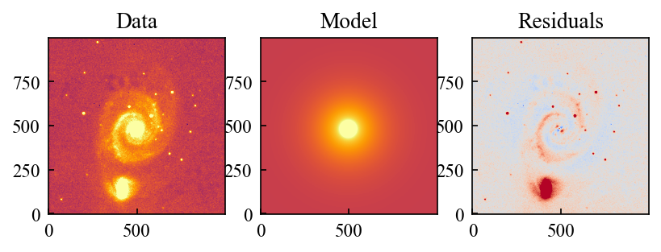

```python
model_image = two_component_model(x, y, np.array(result.x))

import matplotlib.pyplot as plt
plt.subplot(1, 3, 1)
plt.title('Data')
plt.imshow(data, origin='lower', cmap='inferno', vmin = vmin, vmax = vmax)

plt.subplot(1, 3, 2)
plt.title('Model')
plt.imshow(model_image, origin='lower', cmap='inferno', vmin = vmin, vmax = vmax)

plt.subplot(1, 3, 3)
plt.title('Residuals')
plt.imshow(data - model_image, origin='lower', cmap='coolwarm', vmin = vmin, vmax = vmax)
plt.show()

#xlearly, the sersic profile is beinmg affected by the spiral arms
#which is shown in the residuals plot
#thus masking pout the spiral arms may be a necessary step to getting a better fit.
```

```python
#now try fitting to the disk profile by removing the center bulge entirely
#to see if the fit becomes becomes better after doing so
```

```python
from astropy.convolution import Gaussian2DKernel, convolve

kernel = Gaussian2DKernel(x_stddev=20)  # tune stddev to smooth scale
smooth = convolve(data, kernel)


residual = data - smooth

sigma = np.std(residual)
threshold = sigma

R_bulge = 50  # adjust based on your galaxy
yy, xx = np.indices(data.shape)
r = np.sqrt((xx - 500)**2 + (yy - 500)**2)
central_mask = r < R_bulge

# Mask = True where pixels are *not* spiral arms (we want to keep them)
#but we also need to avoid masking out the central bulge.
mask0 = np.abs(residual) < threshold
mask = mask0


data_corr = np.where(mask, data, np.median(data))


y = np.zeros(shape = data_corr.shape, dtype = int)
x = np.zeros(shape = data_corr.shape, dtype = int)
for i in range(len(y[0])):
    y[i] += len(y[0]) - (i+1)
    x[:,i] += i



p1 = [np.max(data), 50, 4, np.max(data)/1.5, 200, 1, 500, 500]
bounds_lower = [0, 1, .5, 0, 10, .5, 0, 0]
bounds_upper = [np.inf, 200, 8, np.inf, 500, 8, data.shape[1], data.shape[0]]


result = least_squares(residuals_two_components, p1, args=(x, y, data_corr), bounds=(bounds_lower, bounds_upper))

I_e_bulge_fit, R_e_bulge_fit, n_bulge_fit, I_e_disk_fit, R_e_disk_fit, n_disc_fit, x0_fit, y0_fit = result.x

print(f"Smoothed Fit results:")
print(f"Bulge: I_e={I_e_bulge_fit:.2f}, R_e={R_e_bulge_fit:.2f}, n={n_bulge_fit:.2f}")
print(f"Disk: I_e={I_e_disk_fit:.2f}, R_e={R_e_disk_fit:.2f}, n={n_disc_fit:.2f}")
print(f"Center: x0={x0_fit:.2f}, y0={y0_fit:.2f}")
```

```
Smoothed Fit results:
Bulge: I_e=0.00, R_e=1.00, n=0.50
Disk: I_e=0.06, R_e=178.04, n=0.84
Center: x0=486.89, y0=529.90
```

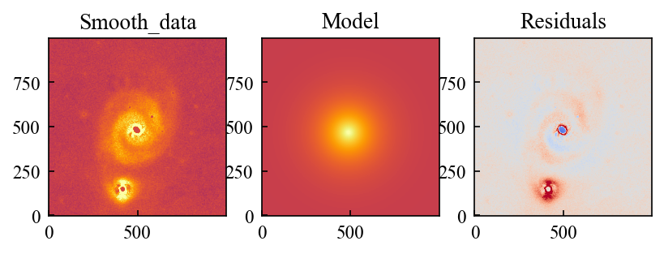

```python
model_image = two_component_model(x, y, np.array(result.x))

import matplotlib.pyplot as plt
plt.subplot(1, 3, 1)
plt.title('Smooth_data')
plt.imshow(data_corr, origin='lower', cmap='inferno', vmin = vmin, vmax = vmax)

plt.subplot(1, 3, 2)
plt.title('Model')
plt.imshow(model_image, origin='lower', cmap='inferno', vmin = vmin, vmax = vmax)

plt.subplot(1, 3, 3)
plt.title('Residuals')
plt.imshow(data_corr - model_image, origin='lower', cmap='coolwarm', vmin = vmin, vmax = vmax)
plt.show()

#xlearly, the sersic profile is beinmg affected by the spiral arms
#which is shown in the residuals plot
#While the bulge plot is no longer accurate
#as the bulge is filtered out
#the model sersic fit is much closer to what we expect
#and the residual plot looks much bteter for the outside.
```

```python
iband.close()
rband.close()
gband.close()
```

## Basic Analysis for M51

- Our first model fits just for the bulge, and retrieves a sersic index of 2.33, which is fairly accurate for the bulge of a spiral galaxy, but obviously a severe over-estimation for the disc halo. This can be seen in the model plot, which fits very well for the bulge, but doesn't consider the light halo of the rest of the galaxy at all.
- We get a slightly better estimation when switching to a 2 component model, with a value of .77 for the disc halo, which is an underestimation, but much more reasonable. The two component model, however, also severly underestimates the index of the bulge, giving a value of only 1.05, which is far too diffuse.
- The best value may actually be from a combinatiomn of these two models, which could be an interesting hypothesis to test in an extension to this project.
- Finally, the best value we retrieve for the disc is when we remove the vbulge entirely, along with smoothing away the spiral arms slightly, which gives us a value of .84, which is very reasonable, especially considering that SEO has very low angular resoltion,a nd thus it is reasonable to assume that some smoothing and spreading out of the light profile may be taking place. This fit also has the best residual plot, apart form the center, suggesting it may be the most accurate of the three methods, at least for fitting the disk model.
- All three models fail to capture the spiral arms in any meaningful way, as evidenced by the residual plots.

## Model Fitting for M101

```python
iband0 = fits.open("/Users/jackcolvin//m101_i-band_120.0s_bin1_250603_053348_jackcolvin_seo_0_FCAL.fits")
gband0 = fits.open("/Users/jackcolvin/m101_g-band_120.0s_bin1_250603_053050_jackcolvin_seo_0_FCAL.fits")
rband0 = fits.open("/Users/jackcolvin//m101_r-band_120.0s_bin1_250603_052816_jackcolvin_seo_0_FCAL.fits")
```

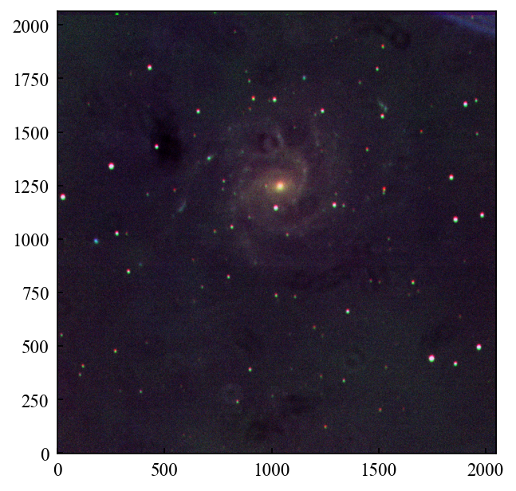

```python
r0 = iband0[0].data
g0 = rband0[0].data
b0 = gband0[0].data

#lupton_rgb doesn't support scaling
#so that must be done manually
zscale = ZScaleInterval()
r_scaled0 = zscale(r0)
g_scaled0 = zscale(g0)
b_scaled0 = zscale(b0)



image = make_lupton_rgb(r_scaled0, .9*g_scaled0, b_scaled0, Q = 1, stretch = .7, minimum = .25)
plt.imshow(image, origin = 'lower')
plt.show()
```

```
Fit: I_e = 0.00152, R_e = 2192.04, n = 4.42, x0 = 237.36, y0 = 298.53
```

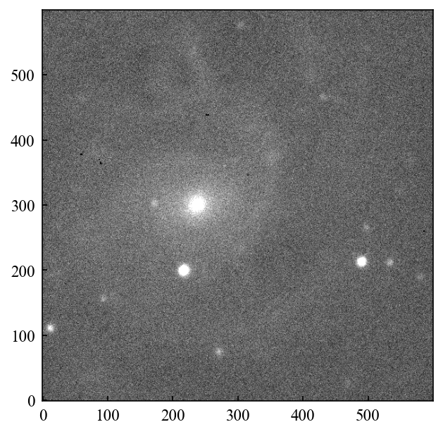

```python
#Now we must find a best fit sersic profile
#and see if our best fit index fits our prediction
#based on whether this galaxy is spiral or elliptical.
#also check to see how different the function is across different bands
from scipy.optimize import least_squares
import matplotlib.pyplot as plt

scale_factor = 10000 #rescale calibrated fluxes as they are so small
cutout = Cutout2D(r0, (1100, 1250), (600, 600))
data0 = cutout.data
data = (data0-np.median(r0))*scale_factor
interval = ZScaleInterval()
vmin,vmax = interval.get_limits(data)
plt.imshow(data, origin = 'lower', cmap = 'gray', vmin = vmin, vmax = vmax )


y = np.zeros(shape = data.shape, dtype = int)
x = np.zeros(shape = data.shape, dtype = int)
for i in range(len(y[0])):
    y[i] += len(y[0]) - (i+1)
    x[:,i] += i


#define an example sersic profile:
def sersic_2d(x, y, I_e, R_e, n, x0, y0):
    r = np.sqrt((x - x0)**2 + (y - y0)**2)
    b_n = 2 * n - 1/3 + (4/(405*n)) + (46/(25515*n**2))
    return I_e * np.exp(-b_n * ((r / R_e)**(1/n) - 1))

def residuals(params, x, y, data):
    I_e, R_e, n, x0, y0 = params
    model = sersic_2d(x, y, I_e, R_e, n, x0, y0)
    return (model - data).ravel()

p0 = [np.max(data), 50, 1.0, 250, 300] #guess the expected sersic index for a spiral galaxy
result = least_squares(residuals, p0, args=(x, y, data), bounds=([0, 1, 0.1, 0, 0], [np.inf, np.inf, 10, 500, 500]))

I_e_fit, R_e_fit, n_fit, x0_fit, y0_fit = result.x
print(f"Fit: I_e = {I_e_fit:.5f}, R_e = {R_e_fit:.2f}, n = {n_fit:.2f}, x0 = {x0_fit:.2f}, y0 = {y0_fit:.2f}")
```

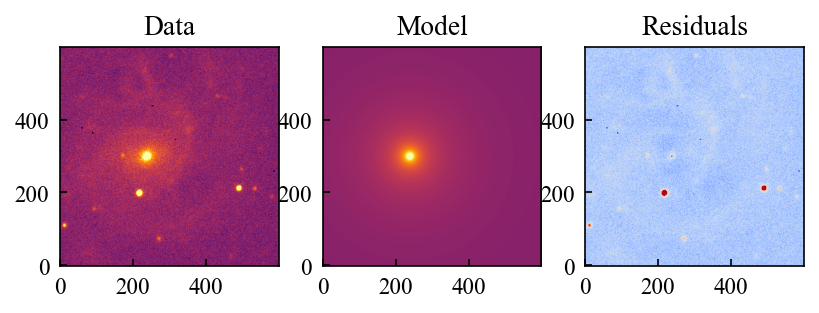

```python
model_image = sersic_2d(x, y, *result.x)

import matplotlib.pyplot as plt
plt.subplot(1, 3, 1)
plt.title('Data')
plt.imshow(data, origin='lower', cmap='inferno', vmin = vmin, vmax = vmax)

plt.subplot(1, 3, 2)
plt.title('Model')
plt.imshow(model_image, origin='lower', cmap='inferno',  vmin = vmin, vmax = vmax)

plt.subplot(1, 3, 3)
plt.title('Residuals')
plt.imshow(data - model_image, origin='lower', cmap='coolwarm',  vmin = vmin, vmax = vmax )
plt.show()
```

```python
p1 = [np.max(data), 10, 4, np.max(data)/1.5, 200, 1, 300, 280]
bounds_lower = [0, 1, 2, 0, 10, .5, 0, 0]
bounds_upper = [np.inf, 200, 8, np.inf, 500, 8, data.shape[1], data.shape[0]]


result = least_squares(residuals_two_components, p1, args=(x, y, data), bounds=(bounds_lower, bounds_upper))

I_e_bulge_fit, R_e_bulge_fit, n_bulge_fit, I_e_disk_fit, R_e_disk_fit, n_disc_fit, x0_fit, y0_fit = result.x

print(f"Fit results:")
print(f"Bulge: I_e={I_e_bulge_fit:.2f}, R_e={R_e_bulge_fit:.2f}, n={n_bulge_fit:.2f}")
print(f"Disk: I_e={I_e_disk_fit:.2f}, R_e={R_e_disk_fit:.2f}, n={n_disc_fit:.2f}")
print(f"Center: x0={x0_fit:.2f}, y0={y0_fit:.2f}")
```

```
Fit results:
Bulge: I_e=0.06, R_e=48.55, n=2.00
Disk: I_e=0.04, R_e=270.66, n=0.92
Center: x0=237.33, y0=298.52
```

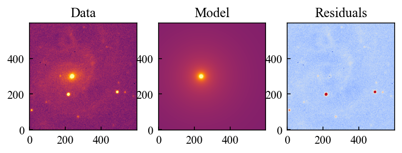

```python
model_image = two_component_model(x, y, np.array(result.x))

import matplotlib.pyplot as plt
plt.subplot(1, 3, 1)
plt.title('Data')
plt.imshow(data, origin='lower', cmap='inferno', vmin = vmin, vmax = vmax)

plt.subplot(1, 3, 2)
plt.title('Model')
plt.imshow(model_image, origin='lower', cmap='inferno', vmin = vmin, vmax = vmax)

plt.subplot(1, 3, 3)
plt.title('Residuals')
plt.imshow(data - model_image, origin='lower', cmap='coolwarm', vmin = vmin, vmax = vmax)
plt.show()

#xlearly, the sersic profile is beinmg affected by the spiral arms
#which is shown in the residuals plot
#thus masking pout the spiral arms may be a necessary step to getting a better fit.
```

```python
def two_component_ellipse(x, y, params):
    # params = [I_e_bulge, R_e_bulge, n_bulge, q_bulge, theta_bulge, I_e_disk, R_e_disk, q_disk, theta_disk, x0, y0]
    I_e_bulge, R_e_bulge, n_bulge, q_bulge, theta_bulge, I_e_disk, R_e_disk, n_disk, q_disk, theta_disk, x0, y0 = params
    bulge = sersic_2d_elliptical(x, y, I_e_bulge, R_e_bulge, n_bulge, x0, y0, q_bulge, theta_bulge)
    disk = sersic_2d_elliptical(x, y, I_e_disk, R_e_disk, n_disk, x0, y0, q_disk, theta_disk)
    return bulge + disk

def residuals_two_ellipse(params, x, y, data):
    model = two_component_ellipse(x, y, params)
    return (model - data).ravel()


p1 = [np.max(data), 15, 4, .5, 1, np.max(data)/2, 200, 1, .5, 1, 230, 270]
bounds_lower = [0, 0, 2, 0, 0, 0, 50, .5, 0, 0, 0, 0]
bounds_upper = [np.inf, 50, 6, 1, 2*np.pi, np.inf, 400, 8, 1, 2*np.pi, data.shape[1], data.shape[0]]


result = least_squares(residuals_two_ellipse, p1, args=(x, y, data), bounds=(bounds_lower, bounds_upper))

I_e_bulge_fit, R_e_bulge_fit, n_bulge_fit, q_bulge_fit, theta_bulge_fit, I_e_disk_fit, R_e_disk_fit, n_disc_fit, q_disc_fit, theta_disc_fit, x0_fit, y0_fit = result.x

print(f"Fit results:")
print(f"Bulge: I_e={I_e_bulge_fit:.2f}, R_e={R_e_bulge_fit:.2f}, n={n_bulge_fit:.2f}, q ={q_bulge_fit:.2f}, theta = {theta_bulge_fit:.2f}")
print(f"Disk: I_e={I_e_disk_fit:.2f}, R_e={R_e_disk_fit:.2f}, n={n_disc_fit:.2f}, q={q_disc_fit:.2f}, theta={theta_disc_fit:.2f}")
print(f"Center: x0={x0_fit:.2f}, y0={y0_fit:.2f}")
```

```
Fit results:
Bulge: I_e=0.07, R_e=50.00, n=2.00, q =0.81, theta = 5.98
Disk: I_e=0.03, R_e=313.05, n=1.01, q=0.80, theta=2.54
Center: x0=237.30, y0=298.50
```

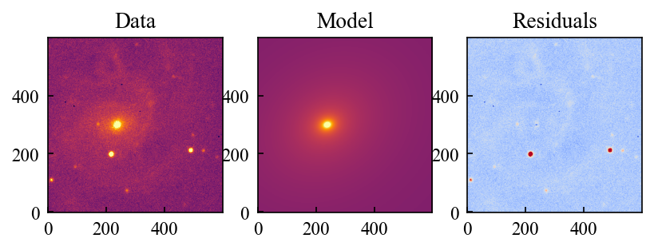

```python
model_image = two_component_ellipse(x, y, np.array(result.x))

import matplotlib.pyplot as plt
plt.subplot(1, 3, 1)
plt.title('Data')
plt.imshow(data, origin='lower', cmap='inferno', vmin = vmin, vmax = vmax)

plt.subplot(1, 3, 2)
plt.title('Model')
plt.imshow(model_image, origin='lower', cmap='inferno', vmin = vmin, vmax = vmax)

plt.subplot(1, 3, 3)
plt.title('Residuals')
plt.imshow(data - model_image, origin='lower', cmap='coolwarm', vmin = vmin, vmax = vmax)
plt.show()

#xlearly, the sersic profile is beinmg affected by the spiral arms
#which is shown in the residuals plot
#thus masking pout the spiral arms may be a necessary step to getting a better fit.
```

```python
iband0.close()
gband0.close()
rband0.close()
```

```python
iband01 = fits.open("/Users/jackcolvin//m81_i-band_120.0s_bin1_250603_055612_jackcolvin_seo_0_FCAL.fits")
gband01 = fits.open("/Users/jackcolvin//m81_g-band_120.0s_bin1_250603_055340_jackcolvin_seo_0_FCAL.fits")
rband01 = fits.open("/Users/jackcolvin//m81_r-band_120.0s_bin1_250603_055109_jackcolvin_seo_0_FCAL.fits")
```

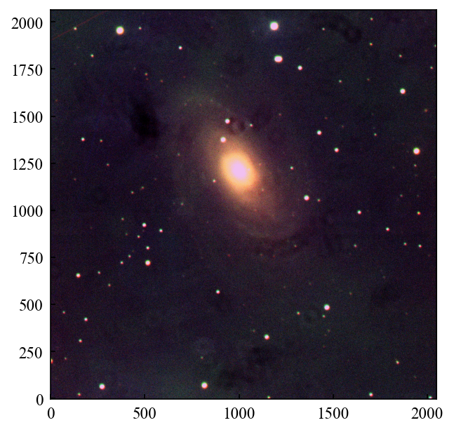

```python
r01 = iband01[0].data
g01 = rband01[0].data
b01 = gband01[0].data

#lupton_rgb doesn't support scaling
#so that must be done manually
zscale = ZScaleInterval()
r_scaled01 = zscale(r01)
g_scaled01 = zscale(g01)
b_scaled01 = zscale(b01)



image = make_lupton_rgb(r_scaled01, .85*g_scaled01, b_scaled01, Q = 1, stretch = .7, minimum = .25)
plt.imshow(image, origin = 'lower')
plt.show()
```

```
Fit: I_e = 0.20730, R_e = 148.97, n = 3.14, x0 = 501.55, y0 = 491.44
```

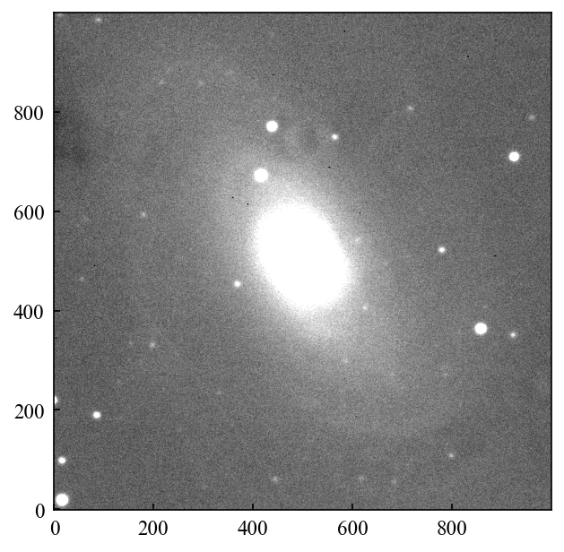

```python
scale_factor = 10000 #rescale calibrated fluxes as they are so small
cutout = Cutout2D(r01, (1000, 1200), (1000, 1000))
data0 = cutout.data
data = (data0-np.median(r01))*scale_factor
interval = ZScaleInterval()
vmin,vmax = interval.get_limits(data)
plt.imshow(data, origin = 'lower', cmap = 'gray', vmin = vmin, vmax = vmax )


y = np.zeros(shape = data.shape, dtype = int)
x = np.zeros(shape = data.shape, dtype = int)
for i in range(len(y[0])):
    y[i] += len(y[0]) - (i+1)
    x[:,i] += i


#define an example sersic profile:
def sersic_2d(x, y, I_e, R_e, n, x0, y0):
    r = np.sqrt((x - x0)**2 + (y - y0)**2)
    b_n = 2 * n - 1/3 + (4/(405*n)) + (46/(25515*n**2))
    return I_e * np.exp(-b_n * ((r / R_e)**(1/n) - 1))

def residuals(params, x, y, data):
    I_e, R_e, n, x0, y0 = params
    model = sersic_2d(x, y, I_e, R_e, n, x0, y0)
    return (model - data).ravel()

p0 = [np.max(data), 50, 1.0, 500, 500] #guess the expected sersic index for a spiral galaxy
result = least_squares(residuals, p0, args=(x, y, data), bounds=([0, 1, 0.1, 0, 0], [np.inf, np.inf, 10, 600, 600]))

I_e_fit, R_e_fit, n_fit, x0_fit, y0_fit = result.x
print(f"Fit: I_e = {I_e_fit:.5f}, R_e = {R_e_fit:.2f}, n = {n_fit:.2f}, x0 = {x0_fit:.2f}, y0 = {y0_fit:.2f}")
```

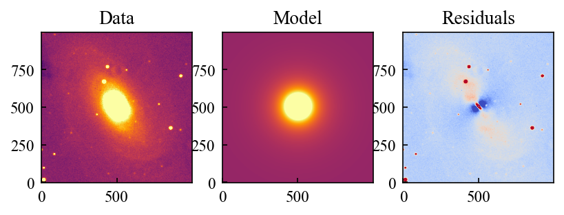

```python
model_image = sersic_2d(x, y, *result.x)

import matplotlib.pyplot as plt
plt.subplot(1, 3, 1)
plt.title('Data')
plt.imshow(data, origin='lower', cmap='inferno', vmin = vmin, vmax = vmax)

plt.subplot(1, 3, 2)
plt.title('Model')
plt.imshow(model_image, origin='lower', cmap='inferno',  vmin = vmin, vmax = vmax)

plt.subplot(1, 3, 3)
plt.title('Residuals')
plt.imshow(data - model_image, origin='lower', cmap='coolwarm',  vmin = vmin, vmax = vmax )
plt.show()

#a circularly symetric model does a bad job for this galaxy
#so now we must define an ellipse
```

```python
def sersic_2d_elliptical(x, y, I_e, R_e, n, x0, y0, q, theta):
    x_shift = x - x0
    y_shift = y - y0
    x_rot = x_shift * np.cos(theta) + y_shift * np.sin(theta)
    y_rot = -x_shift * np.sin(theta) + y_shift * np.cos(theta)
    R = np.sqrt(x_rot**2 + (y_rot / q)**2)
    b_n = 2 * n - 1/3 + (4/(405*n)) + (46/(25515*n**2))
    return I_e * np.exp(-b_n * ((R / R_e)**(1/n) - 1))

def residuals_elliptical(params, x, y, data):
    I_e, R_e, n, x0, y0, q, theta = params
    model = sersic_2d_elliptical(x, y, I_e, R_e, n, x0, y0, q, theta)
    return (model - data).ravel()

p0 = [np.max(data), 50, 1.0, 500, 500, .5, np.pi/3] #guess the expected sersic index for a spiral galaxy
result = least_squares(residuals_elliptical, p0, args=(x, y, data), bounds=([0, 1, 0.1, 0, 0, 0, 0], [np.inf, np.inf, 10, 600, 600, 1, 2*np.pi]))

I_e_fit, R_e_fit, n_fit, x0_fit, y0_fit, q_fit, theta_fit = result.x
print(f"Fit: I_e = {I_e_fit:.5f}, R_e = {R_e_fit:.2f}, n = {n_fit:.2f}, x0 = {x0_fit:.2f}, y0 = {y0_fit:.2f}, q = {q_fit:.2f}, theta = {theta_fit:.2f}")
```

```
Fit: I_e = 0.20369, R_e = 181.48, n = 3.14, x0 = 501.58, y0 = 491.36, q = 0.71, theta = 0.99
```

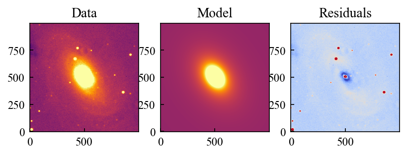

```python
model_image = sersic_2d_elliptical(x, y, *result.x)

import matplotlib.pyplot as plt
plt.subplot(1, 3, 1)
plt.title('Data')
plt.imshow(data, origin='lower', cmap='inferno', vmin = vmin, vmax = vmax)

plt.subplot(1, 3, 2)
plt.title('Model')
plt.imshow(model_image, origin='lower', cmap='inferno',  vmin = vmin, vmax = vmax)

plt.subplot(1, 3, 3)
plt.title('Residuals')
plt.imshow(data - model_image, origin='lower', cmap='coolwarm',  vmin = vmin, vmax = vmax )
plt.show()
```

```python
p1 = [np.max(data), 50, 4, .5, 1, np.max(data)/1.5, 200, 1, .5, 1, 500, 500]
bounds_lower = [0, 1, .5, 0, 0, 0, 10, .5, 0, 0, 0, 0]
bounds_upper = [np.inf, 200, 8, 1, 2*np.pi, np.inf, 500, 8, 1, 2*np.pi, data.shape[1], data.shape[0]]


result = least_squares(residuals_two_ellipse, p1, args=(x, y, data), bounds=(bounds_lower, bounds_upper))

I_e_bulge_fit, R_e_bulge_fit, n_bulge_fit, q_bulge_fit, theta_bulge_fit, I_e_disk_fit, R_e_disk_fit, n_disc_fit, q_disc_fit, theta_disc_fit, x0_fit, y0_fit = result.x

print(f"Fit results:")
print(f"Bulge: I_e={I_e_bulge_fit:.2f}, R_e={R_e_bulge_fit:.2f}, n={n_bulge_fit:.2f}, q ={q_bulge_fit:.2f}, theta = {theta_bulge_fit:.2f}")
print(f"Disk: I_e={I_e_disk_fit:.2f}, R_e={R_e_disk_fit:.2f}, n={n_disc_fit:.2f}, q={q_disc_fit:.2f}, theta={theta_disc_fit:.2f}")
print(f"Center: x0={x0_fit:.2f}, y0={y0_fit:.2f}")
```

```
Fit results:
Bulge: I_e=3.00, R_e=14.68, n=0.98, q =0.83, theta = 0.71
Disk: I_e=0.22, R_e=206.61, n=1.75, q=0.60, theta=1.06
Center: x0=501.58, y0=491.31
```

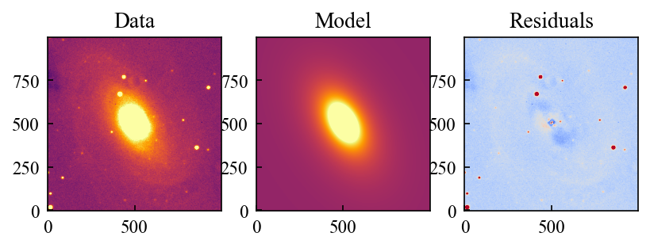

```python
model_image = two_component_ellipse(x, y, np.array(result.x))

import matplotlib.pyplot as plt
plt.subplot(1, 3, 1)
plt.title('Data')
plt.imshow(data, origin='lower', cmap='inferno', vmin = vmin, vmax = vmax)

plt.subplot(1, 3, 2)
plt.title('Model')
plt.imshow(model_image, origin='lower', cmap='inferno', vmin = vmin, vmax = vmax)

plt.subplot(1, 3, 3)
plt.title('Residuals')
plt.imshow(data - model_image, origin='lower', cmap='coolwarm', vmin = vmin, vmax = vmax)
plt.show()
```

```python
p1 = [np.max(data), 50, 5, .5, 1, np.max(data)/2, 200, 1, .5, 1, 500, 500]
bounds_lower = [0, 10, 2.5, 0, 0, 0, 0, .5, 0, 0, 0, 0]
bounds_upper = [np.inf, 50, 6, 1, 2*np.pi, np.inf, 500, 8, 1, 2*np.pi, data.shape[1], data.shape[0]]


result = least_squares(residuals_two_ellipse, p1, args=(x, y, data), bounds=(bounds_lower, bounds_upper))

I_e_bulge_fit, R_e_bulge_fit, n_bulge_fit, q_bulge_fit, theta_bulge_fit, I_e_disk_fit, R_e_disk_fit, n_disc_fit, q_disc_fit, theta_disc_fit, x0_fit, y0_fit = result.x

print(f"Fit results:")
print(f"Bulge: I_e={I_e_bulge_fit:.2f}, R_e={R_e_bulge_fit:.2f}, n={n_bulge_fit:.2f}, q ={q_bulge_fit:.2f}, theta = {theta_bulge_fit:.2f}")
print(f"Disk: I_e={I_e_disk_fit:.2f}, R_e={R_e_disk_fit:.2f}, n={n_disc_fit:.2f}, q={q_disc_fit:.2f}, theta={theta_disc_fit:.2f}")
print(f"Center: x0={x0_fit:.2f}, y0={y0_fit:.2f}")
```

```
Fit results:
Bulge: I_e=1.33, R_e=10.00, n=2.50, q =0.02, theta = 3.22
Disk: I_e=0.20, R_e=182.42, n=3.14, q=0.71, theta=1.00
Center: x0=501.57, y0=491.45
```

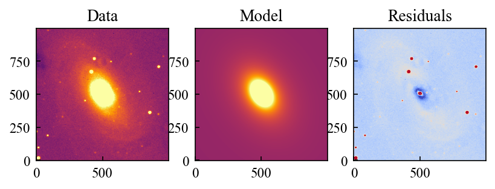

```python
model_image = two_component_ellipse(x, y, np.array(result.x))

import matplotlib.pyplot as plt
plt.subplot(1, 3, 1)
plt.title('Data')
plt.imshow(data, origin='lower', cmap='inferno', vmin = vmin, vmax = vmax)

plt.subplot(1, 3, 2)
plt.title('Model')
plt.imshow(model_image, origin='lower', cmap='inferno', vmin = vmin, vmax = vmax)

plt.subplot(1, 3, 3)
plt.title('Residuals')
plt.imshow(data - model_image, origin='lower', cmap='coolwarm', vmin = vmin, vmax = vmax)
plt.show()
```

```python
iband01.close()
gband01.close()
rband01.close()
```

## Model Fitting for M89

```python
iband1 = fits.open("/Users/jackcolvin//m89_i-band_120.0s_bin1_250603_045958_jackcolvin_seo_0_FCAL.fits")
gband1 = fits.open("/Users/jackcolvin//m89_g-band_120.0s_bin1_250603_045721_jackcolvin_seo_0_FCAL.fits")
rband1 = fits.open("/Users/jackcolvin//m89_r-band_120.0s_bin1_250603_045449_jackcolvin_seo_0_FCAL.fits")
```

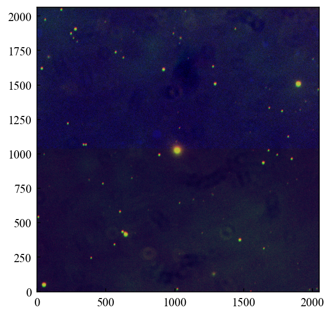

```python
from astropy.visualization.lupton_rgb import make_lupton_rgb
from astropy.visualization import LogStretch


r1 = iband1[0].data
g1 = rband1[0].data
b1 = gband1[0].data

#lupton_rgb doesn't support scaling
#so that must be done manually
zscale = ZScaleInterval()
r_scaled1 = zscale(r1)
g_scaled1 = zscale(g1)
b_scaled1 = zscale(b1)



image = make_lupton_rgb(r_scaled1, g_scaled1, b_scaled1, Q = 1, stretch = .9, minimum = .3)
plt.imshow(image, origin = 'lower')
plt.show()
```

```
Fit: I_e = 1.13535, R_e = 17.60, n = 1.50, x0 = 266.66, y0 = 318.41
```

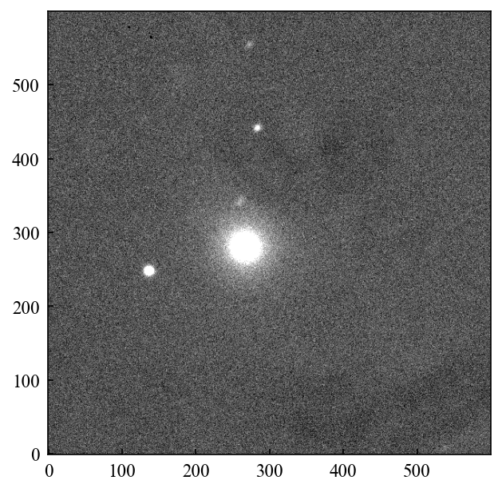

```python
#Now we must find a best fit sersic profile
#and see if our best fit index fits our prediction
#based on whether this galaxy is spiral or elliptical.
#also check to see how different the function is across different bands
from scipy.optimize import least_squares
import matplotlib.pyplot as plt

scale_factor = 10000 #rescale calibrated fluxes as they are so small
cutout = Cutout2D(r1, (1050, 1050), (600, 600))
data0 = cutout.data
data = (data0-np.median(r1))*scale_factor
interval = ZScaleInterval()
vmin,vmax = interval.get_limits(data)
plt.imshow(data, origin = 'lower', cmap = 'gray', vmin = vmin, vmax = vmax )


y = np.zeros(shape = data.shape, dtype = int)
x = np.zeros(shape = data.shape, dtype = int)
for i in range(len(y[0])):
    y[i] += len(y[0]) - (i+1)
    x[:,i] += i

p0 = [np.max(data), 10, 4, 300, 300] #guess the expected sersic index for a spiral galaxy
result = least_squares(residuals, p0, args=(x, y, data), bounds=([0, 1, 0.1, 0, 0], [np.inf, np.inf, 10, 500, 500]))

I_e_fit, R_e_fit, n_fit, x0_fit, y0_fit = result.x
print(f"Fit: I_e = {I_e_fit:.5f}, R_e = {R_e_fit:.2f}, n = {n_fit:.2f}, x0 = {x0_fit:.2f}, y0 = {y0_fit:.2f}")
```

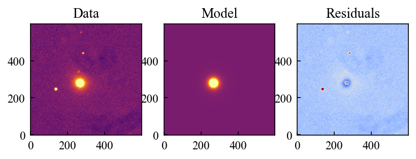

```python
model_image = sersic_2d(x, y, *result.x)

import matplotlib.pyplot as plt
plt.subplot(1, 3, 1)
plt.title('Data')
plt.imshow(data, origin='lower', cmap='inferno', vmin = vmin, vmax = vmax)

plt.subplot(1, 3, 2)
plt.title('Model')
plt.imshow(model_image, origin='lower', cmap='inferno', vmin = vmin, vmax = vmax)

plt.subplot(1, 3, 3)
plt.title('Residuals')
plt.imshow(data - model_image, origin='lower', cmap='coolwarm', vmin = vmin, vmax = vmax)
plt.show()
```

```python
iband1.close()
gband1.close()
rband1.close()
```

## Basic Analysis for M89

- There were much less considerations when fitting for elliptical galaxies than spiral, as for eliptical galaxies, the light is almost all concentrated within the central bulge, and there is not a prominent outer halo nor spiral arms to complicate the model. Therefore, I decided that a simple 1 component model would be sufficient to describe their structure.
- For M89, I got a sersic indec of 1.5, which is a significant understimation of the expected value of n~4 for elliptical galaxies.
- There are several physical reasons I noticed for this however. First of all, SEO has a fairly limited resolution, whcih causes light from point-like, dense sources of light to be spread out over a large area, which could account for the underestimation we see here
- Furthermore, the residual plot shows a similar trend, with the center of the model being an underestimation of the light intensity, and the outside being an overestimation. Therefore, it almost seems visually that a sharper model, and thus one with a larger sersic index, would be a better fit, despite what the residual fitting might return. This is certainly something to be investigated further as i continue to work on this project.

## Model Fitting for m60

```python
iband2 = fits.open("/Users/jackcolvin//m60_i-band_120.0s_bin1_250603_052218_jackcolvin_seo_0_FCAL.fits")
gband2 = fits.open("/Users/jackcolvin//m60_g-band_120.0s_bin1_250603_051942_jackcolvin_seo_0_FCAL.fits")
rband2 = fits.open("/Users/jackcolvin//m60_r-band_120.0s_bin1_250603_051649_jackcolvin_seo_0_FCAL.fits")
```

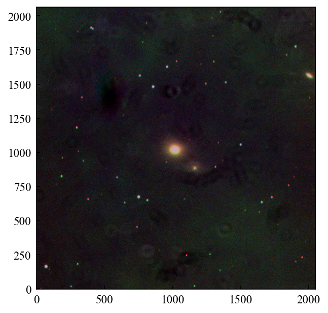

```python
r2 = iband2[0].data
g2 = rband2[0].data
b2 = gband2[0].data

#lupton_rgb doesn't support scaling
#so that must be done manually
zscale = ZScaleInterval()
r_scaled2 = zscale(r2)
g_scaled2 = zscale(g2)
b_scaled2 = zscale(b2)



image = make_lupton_rgb(r_scaled2, .9*g_scaled2, b_scaled2, Q = 1, stretch = .9, minimum = .25)
plt.imshow(image, origin = 'lower')
plt.show()
```

```
Fit: I_e = 0.47759, R_e = 42.67, n = 2.00, x0 = 264.74, y0 = 325.45
```

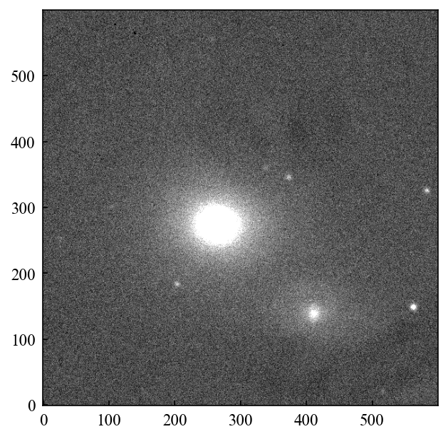

```python
#Now we must find a best fit sersic profile
#and see if our best fit index fits our prediction
#based on whether this galaxy is spiral or elliptical.
#also check to see how different the function is across different bands
from scipy.optimize import least_squares
import matplotlib.pyplot as plt

scale_factor = 10000 #rescale calibrated fluxes as they are so small
cutout = Cutout2D(r2, (1050, 1050), (600, 600))
data0 = cutout.data
data = (data0-np.median(r2))*scale_factor
interval = ZScaleInterval()
vmin,vmax = interval.get_limits(data)
plt.imshow(data, origin = 'lower', cmap = 'gray', vmin = vmin, vmax = vmax )


y = np.zeros(shape = data.shape, dtype = int)
x = np.zeros(shape = data.shape, dtype = int)
for i in range(len(y[0])):
    y[i] += len(y[0]) - (i+1)
    x[:,i] += i

p0 = [np.max(data), 10, 4, 300, 300] #guess the expected sersic index for a spiral galaxy
result = least_squares(residuals, p0, args=(x, y, data), bounds=([0, 1, 0.1, 0, 0], [np.inf, np.inf, 10, 500, 500]))

I_e_fit, R_e_fit, n_fit, x0_fit, y0_fit = result.x
print(f"Fit: I_e = {I_e_fit:.5f}, R_e = {R_e_fit:.2f}, n = {n_fit:.2f}, x0 = {x0_fit:.2f}, y0 = {y0_fit:.2f}")
```

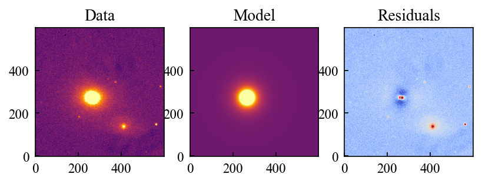

```python
model_image = sersic_2d(x, y, *result.x)

import matplotlib.pyplot as plt
plt.subplot(1, 3, 1)
plt.title('Data')
plt.imshow(data, origin='lower', cmap='inferno', vmin = vmin, vmax = vmax)

plt.subplot(1, 3, 2)
plt.title('Model')
plt.imshow(model_image, origin='lower', cmap='inferno', vmin = vmin, vmax = vmax)

plt.subplot(1, 3, 3)
plt.title('Residuals')
plt.imshow(data - model_image, origin='lower', cmap='coolwarm', vmin = vmin, vmax = vmax)
plt.show()

#again, it seems like the fit is not capturing the true steepness of the real curve
#in a very similar way to the first elliptical.
```

```python
iband2.close()
gband2.close()
rband2.close()
```

## Basic Analysis for M60

- For M60, I got a sersic indec of 2, which, while slightly better than my value for m89, still represents a significant deviation from the expectation for an elliptical galaxy.
- We again see the same pattern, where our residual plot suggests that a sharper model with a higher sersic profile might actually represent a better fit if some outluer points were removed.
- This galaxy is also slightly eliptical, so considering using an elliptical model instead of a circular one may be a good idea when I move forward with this project.

## Model Fitting for M49

```python
iband3 = fits.open("/Users/jackcolvin//m49_i-band_120.0s_bin1_250603_051201_jackcolvin_seo_0_FCAL.fits")
gband3 = fits.open("/Users/jackcolvin//m49_g-band_120.0s_bin1_250603_050926_jackcolvin_seo_0_FCAL.fits")
rband3 = fits.open("/Users/jackcolvin//m49_r-band_120.0s_bin1_250603_050648_jackcolvin_seo_0_FCAL.fits")
```

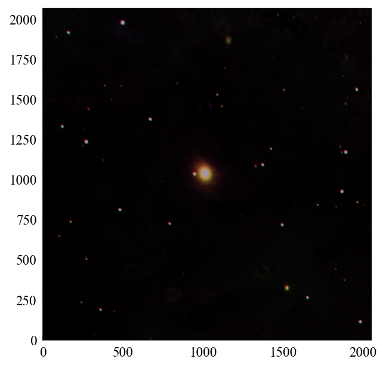

```python
r3 = iband3[0].data
g3 = rband3[0].data
b3 = gband3[0].data

#lupton_rgb doesn't support scaling
#so that must be done manually
zscale = ZScaleInterval()
r_scaled3 = zscale(r3)
g_scaled3 = zscale(g3)
b_scaled3 = zscale(b3)



image = make_lupton_rgb(r_scaled3, .93*g_scaled3, b_scaled3, Q = .5, stretch = .9, minimum = .4)
plt.imshow(image, origin = 'lower')
plt.show()
```

```
Fit: I_e = 0.34682, R_e = 54.06, n = 2.09, x0 = 255.71, y0 = 309.56
```

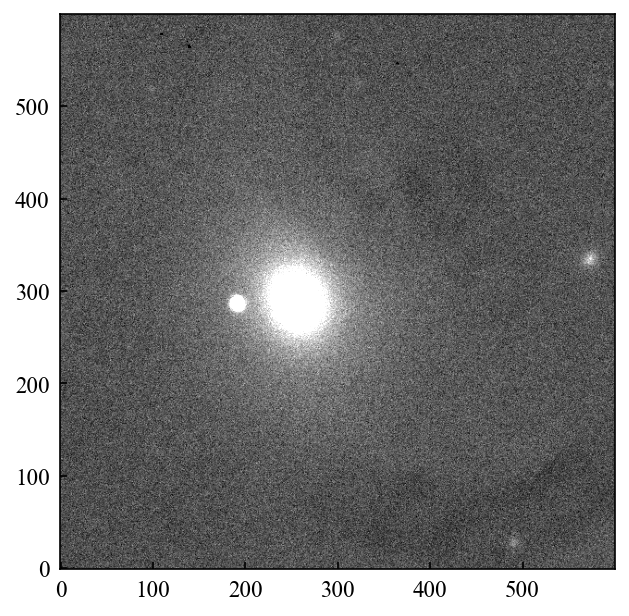

```python
#Now we must find a best fit sersic profile
#and see if our best fit index fits our prediction
#based on whether this galaxy is spiral or elliptical.
#also check to see how different the function is across different bands
from scipy.optimize import least_squares
import matplotlib.pyplot as plt

scale_factor = 10000 #rescale calibrated fluxes as they are so small
cutout = Cutout2D(r3, (1050, 1050), (600, 600))
data0 = cutout.data
data = (data0-np.median(r3))*scale_factor
interval = ZScaleInterval()
vmin,vmax = interval.get_limits(data)
plt.imshow(data, origin = 'lower', cmap = 'gray', vmin = vmin, vmax = vmax )


y = np.zeros(shape = data.shape, dtype = int)
x = np.zeros(shape = data.shape, dtype = int)
for i in range(len(y[0])):
    y[i] += len(y[0]) - (i+1)
    x[:,i] += i

p0 = [np.max(data), 10, 4, 300, 300] #guess the expected sersic index for a spiral galaxy
result = least_squares(residuals, p0, args=(x, y, data), bounds=([0, 1, 0.1, 0, 0], [np.inf, np.inf, 10, 500, 500]))

I_e_fit, R_e_fit, n_fit, x0_fit, y0_fit = result.x
print(f"Fit: I_e = {I_e_fit:.5f}, R_e = {R_e_fit:.2f}, n = {n_fit:.2f}, x0 = {x0_fit:.2f}, y0 = {y0_fit:.2f}")
```

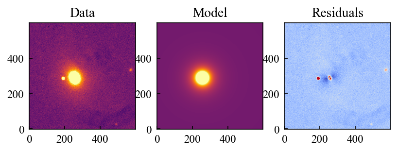

```python
model_image = sersic_2d(x, y, *result.x)

import matplotlib.pyplot as plt
plt.subplot(1, 3, 1)
plt.title('Data')
plt.imshow(data, origin='lower', cmap='inferno', vmin = vmin, vmax = vmax)

plt.subplot(1, 3, 2)
plt.title('Model')
plt.imshow(model_image, origin='lower', cmap='inferno', vmin = vmin, vmax = vmax)

plt.subplot(1, 3, 3)
plt.title('Residuals')
plt.imshow(data - model_image, origin='lower', cmap='coolwarm', vmin = vmin, vmax = vmax)
plt.show()

#again, it seems like the fit is not capturing the true steepness of the real curve
#in a very similar way to the first elliptical.
```

```python
iband3.close()
gband3.close()
rband3.close()
```

- For M49, I got a sersic indec of 2.09, which agrees with my values for m60 and m89, and is slightly closer, but still significantly deviated from, the expected value of 4.
- Furthermore, I again see the same trend in my residuals that suggests a sharper model may be a better fit.

## 3. Discussions and conclusions

I had to deal with significant sources of error throughput my analysis for both eliptical and spiral galaxies. In both cases, the tendency of SEO to spread light across a larger number of pixels due to its limited resolution (3-4 arcseconds) certainly had an impact on my fits. For spiral galaxies, the different light profiles of both the bulge and the spiral arms was a large source of errors that biased by values, and I was only able to partially mitigate those error source by a combination of masking, smoothing, and making a more complex, two-component model. For elliptical galaxies, The limited angular resolution of SEO likely had an even larger effect, as their light is much more similar to a point source, and thus requires high angular resolution to accurately measure. Furthermore, I observed a systematic underapproximation of sersic indeces in all three galaxies, evidenced by residual plots that sugested that a sharper model may actually be a better fit, at least for the central core of the galaxy.

As I continue to work on this project, I have a couple key considerations to keep in mind. First of all, I want to continue tweaking my two-component spiral galaxy model to try to retrieve a model that can simulataneously give me accurate values for both my bulge and my disk. Furthermore, I wasnt to work more on smoothing to lessen the effect that the spiral arms may be having on my sersic fits. For the eliptical galaxies, I want to try to contrain my other parameters apart from sersic index more tightly to see if i can retrieve a model that qualitatively reduced my residuals more effectively. Furthermore, for both cases, I want to both take more SEO eposures, and maybe also try some higher reolution images from the Legacy or SDSS surveys, so try to isolate whether my errors are a result of SEO's poor resolution, or some aspect of my specific analytical techniques.